# FinalRMarkdown

Jordyn Blauer

2025-11-06

# BACKGROUND

Asthma is a lung condition that causes difficulty in breathing due to constricted airways in the lungs. Severity of the condition differs from person to person with some only experiencing minor inconveniences while others can experience debilitating and life-threatening challenges from the disease (Asthma). Because asthma affects the lungs, it is an obvious conclusion that poor air quality can affect those with asthma. However, does the air quality affect the prevalence of asthma per state? We hypothesize that states that have a higher amounts of poor air quality days will have a higher prevalence of asthma. We predict that California will have the most poor air quality days and because of that they will also have the highest rates of asthma compared to other states.

```r
# Load the data
air_data <- data.frame(
  State = c("Alabama", "Alaska", "Arizona", "Arkansas", "California", "Colorado", "Connecticut", "Delaware", "Florida", "Georgia", "Hawaii", "Idaho", "Illinois", "Indiana", "Iowa", "Kansas", "Kentucky", "Louisiana", "Maine", "Maryland", "Massachusetts", "Michigan", "Minnesota", "Mississippi", "Missouri", "Montana", "Nebraska", "Nevada", "New Hampshire", "New Jersey", "New Mexico", "New York", "North Carolina", "North Dakota", "Ohio", "Oklahoma", "Oregon", "Pennsylvania", "Rhode Island", "South Carolina", "South Dakota", "Tennessee", "Texas", "Utah", "Vermont", "Virginia", "Washington", "West Virginia", "Wisconsin", "Wyoming"),
  Poor_Air = c(0.27, 0.12, 0.33, 0.3, 0.46, 0.25, 0.22, 0.31, 0.24, 0.3, 0.03, 0.28, 0.34, 0.25, 0.27, 0.29, 0.23, 0.29, 0.08, 0.19, 0.23, 0.24, 0.14, 0.31, 0.22, 0.19, 0.1, 0.25, 0.1, 0.27, 0.22, 0.16, 0.2, 0.17, 0.25, 0.34, 0.29, 0.31, 0.16, 0.25, 0.15, 0.23, 0.33, 0.29, 0.13, 0.12, 0.24, 0.16, 0.2, 0.15),
  Asthma = c(9.6, 10.7, 9.7, 10.5, 8.7, 10.8, 12.4, 9.9, 9.3, 9.6, 9.1, 11.1, 8.7, 11, 9.7, 10.7, 10.8, 10, 13.1, 10.4, 11.3, 11.9, 9.9, 9.4, 10.4, 11.7, 8.1, 10.1, 13.1, 8.9, 10.4, 10.3, 9.2, 10.4, 11.4, 12.3, 11.5, 10.1, 13.3, 9, 8.3, 11.7, 7.9, 11, 12.9, 9.9, 10.9, 12.9, 10.9, 10.5)
)
```

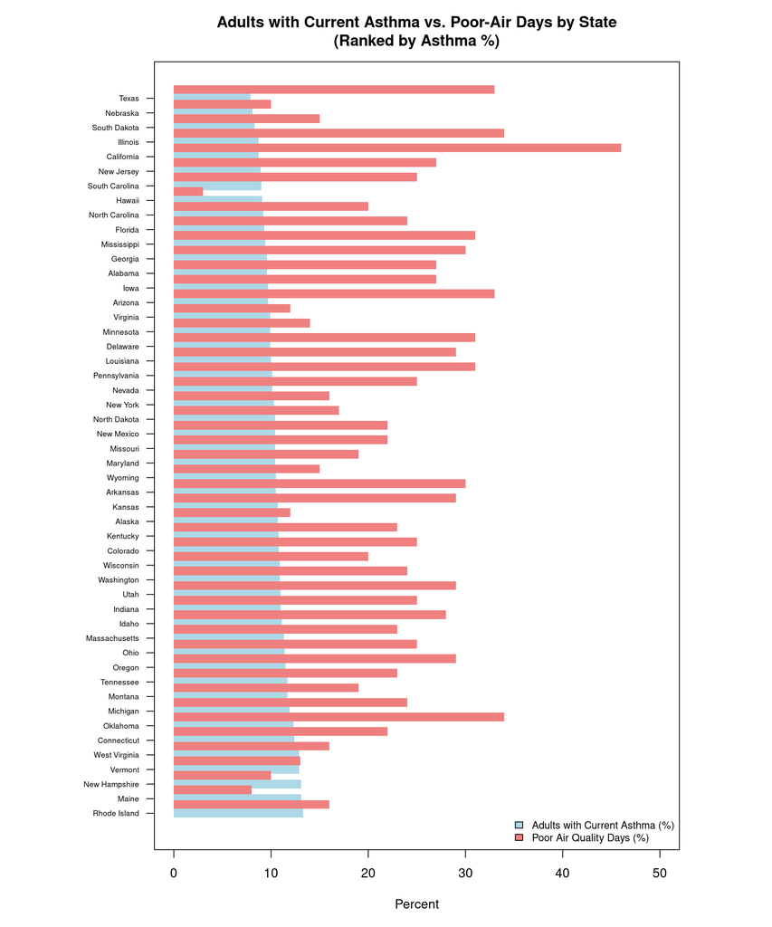

Adults with Current Asthma vs. Poor-Air Days by State (ranked by Asthma %)

```r
# Use the existing air_data from our environment
# Convert to appropriate format and calculate percentages
df <- data.frame(
  State = air_data$State,
  asthma_pct = air_data$Asthma,
  poor_air_pct = air_data$Poor_Air * 100  # Convert proportion to percentage
)

# Sort by asthma percentage (descending)
df <- df[order(-df$asthma_pct), ]

# Set up plotting parameters
par(mar = c(5, 10, 4, 6))  # Adjust margins for state names
y_pos <- 1:nrow(df)  # Y positions for bars

# Create empty plot
plot(0, 0, type = "n",
     xlim = c(0, 50),
     ylim = c(0.5, nrow(df) + 0.5),
     xlab = "Percent",
     ylab = "",
     main = "Adults with Current Asthma vs. Poor-Air Days by State\n(Ranked by Asthma %)",
     yaxt = "n")  # No default y-axis

# Add asthma bars (blue)
barplot_height <- df$asthma_pct
rect(xleft = 0, ybottom = y_pos - 0.3,
     xright = barplot_height, ytop = y_pos + 0.3,
     col = "lightblue", border = NA)

# Add air quality bars (red) - offset slightly
barplot_height_air <- df$poor_air_pct
rect(xleft = 0, ybottom = y_pos - 0.3 + 0.6,
     xright = barplot_height_air, ytop = y_pos + 0.3 + 0.6,
     col = "lightcoral", border = NA)

# Add state names
axis(2, at = y_pos, labels = df$State, las = 1, cex.axis = 0.6)

# Add legend
legend("bottomright",
       legend = c("Adults with Current Asthma (%)", "Poor Air Quality Days (%)"),
       fill = c("lightblue", "lightcoral"),
       cex = 0.8,
       bty = "n")
```

# STUDY QUESTION and HYPOTHESIS

## Questions

Does air quality effect the prevalence of asthma per state?

## Hypothesis

The states with the highest amounts of poor air quality days will also have higher prevalence of asthma.

## Prediction

California will have the highest prevelance of asthma because of its’ high amounts of poor air quality days.

# METHODS/RESULTS

## 1st Analysis

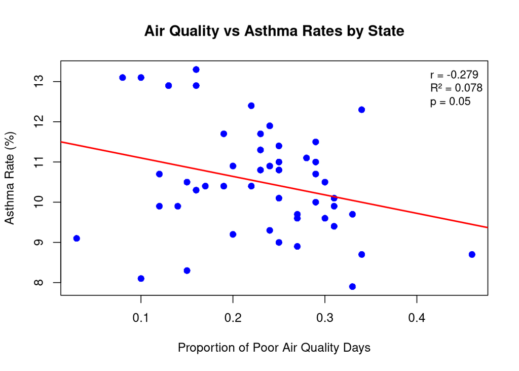

```r
## 1st Analysis: Linear Regression - Air Quality vs Asthma Rates

# Scatter plot with regression line
plot(air_data$Poor_Air, air_data$Asthma,
     xlab = "Proportion of Poor Air Quality Days",
     ylab = "Asthma Rate (%)",
     main = "Air Quality vs Asthma Rates by State",
     pch = 16, col = "blue", cex = 1.2)

# Add regression line
model <- lm(Asthma ~ Poor_Air, data = air_data)
abline(model, col = "red", lwd = 2)

# Calculate statistics
correlation <- cor(air_data$Poor_Air, air_data$Asthma)
r_squared <- summary(model)$r.squared
p_value <- summary(model)$coefficients[2,4]

# Create comprehensive results table
regression_stats <- data.frame(
  Statistic = c("Correlation Coefficient", "R-squared", "Adjusted R-squared",
                "Overall Model p-value", "Regression p-value", "Observations"),
  Value = c(round(correlation, 3),
            round(r_squared, 3),
            round(summary(model)$adj.r.squared, 3),
            round(pf(summary(model)$fstatistic[1], summary(model)$fstatistic[2],
                     summary(model)$fstatistic[3], lower.tail = FALSE), 4),
            round(p_value, 4),
            nrow(air_data))
)


# Add clean statistics to plot
legend("topright",
       legend = c(paste("r =", round(correlation, 3)),
                  paste("R² =", round(r_squared, 3)),
                  paste("p =", ifelse(p_value < 0.001, "< 0.001", round(p_value, 3)))),
       bty = "n", cex = 0.9)
```

```r
# Create coefficients table
coefficients_table <- data.frame(
  Term = c("Intercept", "Poor Air Quality"),
  Estimate = c(round(coef(model)[1], 3), round(coef(model)[2], 3)),
  Std_Error = c(round(summary(model)$coefficients[1,2], 3),
                round(summary(model)$coefficients[2,2], 3)),
  t_value = c(round(summary(model)$coefficients[1,3], 3),
              round(summary(model)$coefficients[2,3], 3)),
  p_value = c(round(summary(model)$coefficients[1,4], 4),
              round(summary(model)$coefficients[2,4], 4))
)

knitr::kable(coefficients_table, caption = "Regression Coefficients")
```

Regression Coefficients

|  | Term | Estimate | Std_Error | t_value | p_value |
| --- | --- | --- | --- | --- | --- |
| (Intercept) | Intercept | 11.560 | 0.554 | 20.873 | 0.0000 |
| Poor_Air | Poor Air Quality | -4.592 | 2.281 | -2.013 | 0.0497 |

```r
# Display model statistics
knitr::kable(regression_stats, caption = "Linear Regression Model Summary")
```

Linear Regression Model Summary

| Statistic | Value |
| --- | --- |
| Correlation Coefficient | -0.2790 |
| R-squared | 0.0780 |
| Adjusted R-squared | 0.0590 |
| Overall Model p-value | 0.0497 |
| Regression p-value | 0.0497 |
| Observations | 50.0000 |

## 2nd Analysis

```r
## 2nd Analysis: T-test comparing asthma rates between high and low pollution states

# Create a new variable for pollution level based on the median of Poor_Air
air_data$Pollution_Level <- ifelse(air_data$Poor_Air > median(air_data$Poor_Air), "High", "Low")
air_data$Pollution_Level <- factor(air_data$Pollution_Level)

# Perform an independent two-sample t-test
t_test_result <- t.test(Asthma ~ Pollution_Level, data = air_data)

# Calculate group means
group_means <- tapply(air_data$Asthma, air_data$Pollution_Level, mean)

# Create a results table
results_table <- data.frame(
  Statistic = c("High Pollution Mean", "Low Pollution Mean",
                "t-statistic", "p-value", "95% CI Lower", "95% CI Upper"),
  Value = c(round(group_means["High"], 2),
            round(group_means["Low"], 2),
            round(t_test_result$statistic, 3),
            round(t_test_result$p.value, 4),
            round(t_test_result$conf.int[1], 3),
            round(t_test_result$conf.int[2], 3))
)

# Display the table
knitr::kable(results_table, caption = "T-Test Results: Asthma Rates by Pollution Level")
```

T-Test Results: Asthma Rates by Pollution Level

| Statistic | Value |
| --- | --- |
| High Pollution Mean | 10.0700 |
| Low Pollution Mean | 10.8800 |
| t-statistic | -2.2740 |
| p-value | 0.0276 |
| 95% CI Lower | -1.5300 |
| 95% CI Upper | -0.0940 |

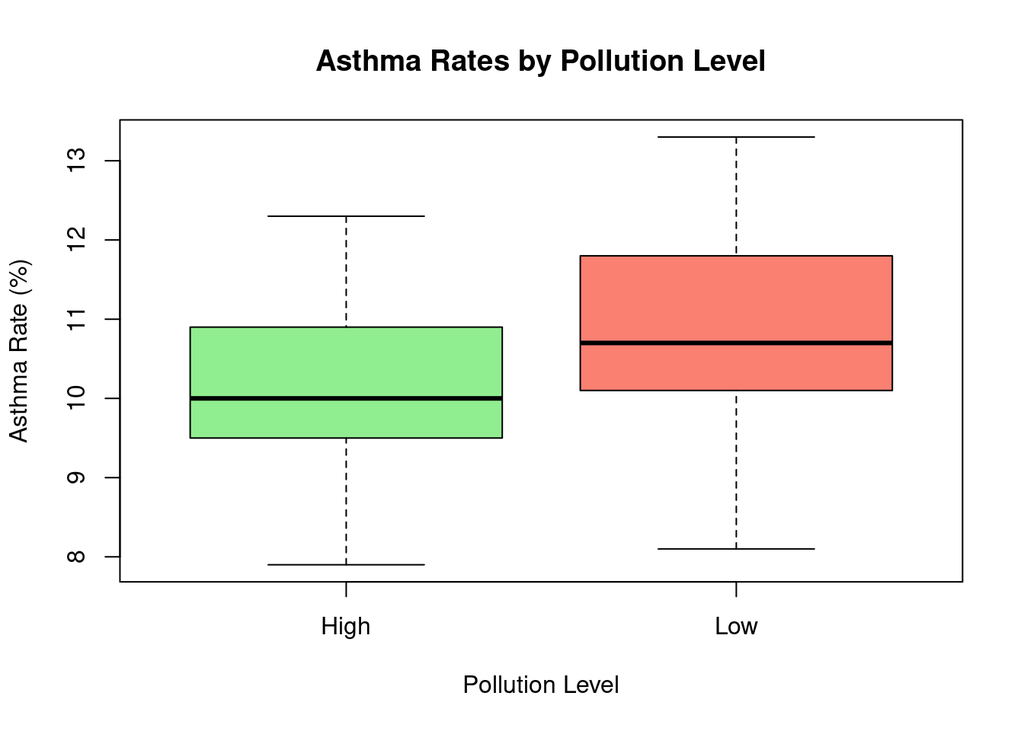

```r
# Create a boxplot to visualize the difference
boxplot(Asthma ~ Pollution_Level,
        data = air_data,
        main = "Asthma Rates by Pollution Level",
        xlab = "Pollution Level",
        ylab = "Asthma Rate (%)",
        col = c("lightgreen", "salmon"))
```

# DISCUSSION

## Interpretation of 1st analysis

## Interpretation of 2nd analysis

# REFERENCES

1. ChatGPT. OpenAI, version Jan 2025. Used as a reference for functions such as plot() and to correct syntax errors. Accessed 2025-11-06.
2. Google. (2025). Gemini (version Oct 2025). Tool used for quick fixes, editing grammar and flow of text, and checking all rubric requirements were met.
3. “Asthma.” Mayo Clinic, Mayo Foundation for Medical Education and Research, 8 Mar. 2025, www.mayoclinic.org/diseases-conditions/asthma/symptoms-causes/syc-20369653.